# 유트브 댓글 - 자연어 처리

깔끔한 텍스트 (Tidytext) - 신년기자회견(2019)

xwMOOC

Tidyverse Korea

2019-01-12

# 1 문재인 대통령 신년기자회견 [^1] [^2]

[2019 문재인 대통령 신년기자회견 연설문](https://www1.president.go.kr/articles/5288)을 웹사이트에서 다운로드받아 연설문 텍스트에서 핵심단어를 추출하고 가장 많이 사용된 단어를 확인하고 이를 [`ggpage`](https://github.com/EmilHvitfeldt/ggpage) 팩키지를 활용하여 시각화하자.

## 1.1 연설문 데이터

[2019 문재인 대통령 신년기자회견 연설문](https://www1.president.go.kr/articles/5288) 웹사이트에서 `rvest`로 연설문만 뽑아내고 기본적인 전처리 작업만한다. `ggplot`으로 시각화하는데 데이터프레임 변환시키고 빈도수가 많은 단어를 공백기준으로 나눠 빈도수를 산출한다.

```r
library(tidyverse)
library(ggpage)
library(rvest)
library(tidytext)

speech_url <- "https://www1.president.go.kr/articles/5288"

speech_text <- read_html(speech_url) %>%
  html_nodes(xpath = '//*[@id="cont_view"]/div/div/div[1]/div[3]') %>%
  html_text() %>%
  str_remove_all("\\n") %>%
  str_remove_all("<U\\+00A0>") %>%
  str_split(pattern="\\.") %>%
  unlist()

speech_df <- tibble(
  line = 1: length(speech_text),
  text = speech_text)

speech_df %>%
  unnest_tokens(word, text) %>%
  count(word, sort = TRUE)
```

```
# A tibble: 1,425 x 2
   word         n
   <chr>    <int>
 1 것입니다    28
 2 수          17
 3 있습니다    14
 4 함께        14
 5 3           13
 6 등          11
 7 만          11
 8 우리        11
 9 우리는      11
10 국민        10
# ... with 1,415 more rows
```

## 1.2 연설문 시각화

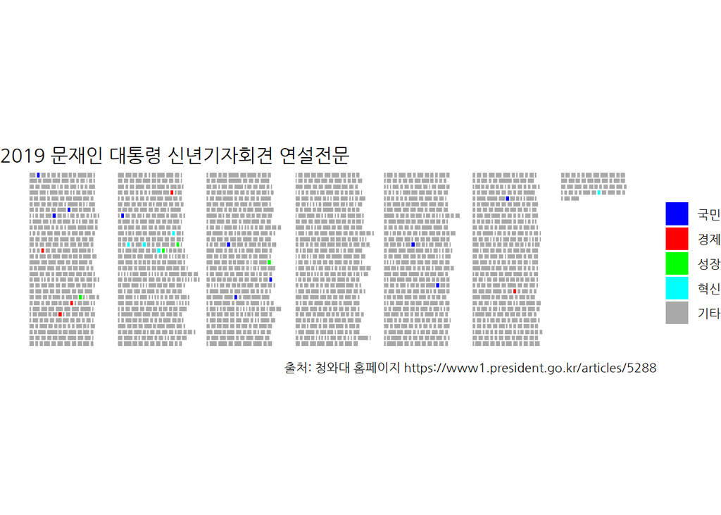

```r
library(extrafont)
loadfonts()

speech_df %>%
  ggpage_build(wtl = TRUE, lpp = 30, x_space_pages =10, y_space_pages = 0, ncol = 7) %>%
  mutate(highlight = case_when(word %in% c("국민") ~ "국민",
                               word %in% c("경제") ~ "경제",
                               word %in% c("성장") ~ "성장",
                               word %in% c("혁신") ~ "혁신",
                               TRUE ~ "기타")) %>%
  mutate(highlight = factor(highlight, levels=c("국민", "경제", "성장", "혁신", "기타"))) %>%
  ggpage_plot(mapping = aes(fill = highlight)) +
  scale_fill_manual(values = c("blue", "red", "green", "cyan", "darkgray")) +
  labs(title = "2019 문재인 대통령 신년기자회견 연설전문",
       caption = "출처: 청와대 홈페이지 https://www1.president.go.kr/articles/5288",
       fill = NULL) +
  theme_void(base_family = "NanumGothic")
```

# 2 한걸음 더 들어갑니다.

앞서 띄어쓰기 기준이 아닌 한국어 고유의 형태소 분석 후 의미있는 단어만 분석할 수 있도록 NLP4kec 팩키지를 활용하여 자연어 처리 분석에 한걸음 더 들어갑니다. `NLP4kec_1.2.0.zip` 파일크기가 1.2GB라서 놀라지 마세요!!!

```r
# install.packages("C:/Users/tidyverse/Downloads/NLP4kec_1.2.0.zip" , repos=NULL)
library(NLP4kec)

speech_bow <- r_parser_r(speech_df$text, language = "ko")

speech_bow_df <- speech_bow %>%
  tibble(line = 1:length(speech_bow), text=.) %>%
  mutate(text = as.character(text))

speech_bow_df %>%
  unnest_tokens(word, text) %>%
  count(word, sort=TRUE)
```

```
# A tibble: 833 x 2
   word      n
   <chr> <int>
 1 것       43
 2 있다     41
 3 경제     35
 4 우리     32
 5 성장     29
 6 국민     24
 7 하다     23
 8 않다     21
 9 혁신     21
10 되다     19
# ... with 823 more rows
```

**사용자 정의 사전(dictionary.txt)**

```r
speech_bow_df %>%
  unnest_tokens(word, text) %>%
  count(word, sort=TRUE) %>%
  filter(word %in% c("포용", "국가", "포용국가"))
```

```
# A tibble: 2 x 2
  word      n
  <chr> <int>
1 국가     18
2 포용      9
```

# 3 tidytext 불용어 처리

먼저 “포용국가” 등을 반영하기 위해서 `korDicPath`를 설정하고 형태소 분석에 들어간다. 그리고 나서 데이터프레임으로 변환작업을 하고 자체 불용어 사전 `tidyverse`를 제작하여 기존 `stop_words` 사전에 결합시킨다. 연설문에 많이 나오는 불용어(stopwords)를 처리하기 위해서 `tidytext` 불용어 사전과 `anti_join()`을 걸어 최종 형태소분석이 깔끔히 완료된 텍스트 데이터를 준비한다.

```r
speech_bow <- r_parser_r(speech_df$text, language = "ko",  korDicPath = "data/dictionary.txt")

speech_bow_df <- speech_bow %>%
  tibble(line = 1:length(speech_bow), text=.) %>%
  mutate(text = as.character(text))

tidy_stopwords <- tibble(
  word = c(
    "것",
    "있다",
    "하다",
    "않다",
    "되다",
    "년",
    "수",
    "위하다",
    "등"
  ),
  lexicon = "tidyverse"
)

all_stop_words <- stop_words %>%
  bind_rows(tidy_stopwords)

speech_bow_df %>%
  unnest_tokens(word, text) %>%
  anti_join(all_stop_words) %>%
  count(word, sort=TRUE) %>%
  DT::datatable()
```

|  | word | n |
| --- | --- | --- |
| 1 | 경제 | 35 |
| 2 | 우리 | 32 |
| 3 | 성장 | 29 |
| 4 | 국민 | 24 |
| 5 | 혁신 | 21 |
| 6 | 정부 | 17 |
| 7 | 올해 | 15 |
| 8 | 평화 | 13 |
| 9 | 국가 | 11 |
| 10 | 문화 | 11 |

[output cut: 815 more lines]

## 3.1 tidytext 연설문 시각화

앞서 형태소 분석 결과를 바탕으로 연설전문에 포용, 경제, 북한, 성장, 혁신 등을 주제로 하여 연설문에 표식을 한다.

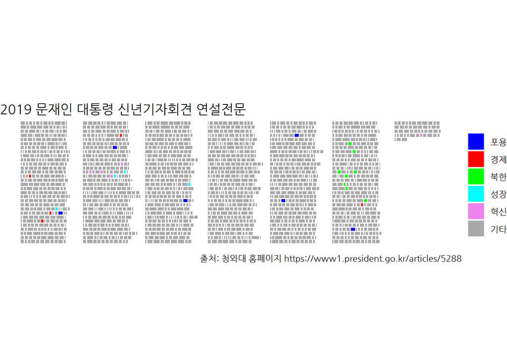

```r
speech_df %>%
  ggpage_build(wtl = TRUE, lpp = 30, x_space_pages =10, y_space_pages = 0, ncol = 7) %>%
  mutate(highlight = case_when(word %in% c("포용적 성장", "포용국가") ~ "포용",
                               word %in% c("경제") ~ "경제",
                               word %in% c("남북", "통일", "북한", "김정은", "개성", "한반도") ~ "북한",
                               word %in% c("성장") ~ "성장",
                               word %in% c("혁신") ~ "혁신",
                               TRUE ~ "기타")) %>%
  mutate(highlight = factor(highlight, levels=c("포용", "경제", "북한", "성장", "혁신", "기타"))) %>%
  ggpage_plot(mapping = aes(fill = highlight)) +
  scale_fill_manual(values = c("blue", "red", "green", "cyan", "violet", "darkgray")) +
  labs(title = "2019 문재인 대통령 신년기자회견 연설전문",
       caption = "출처: 청와대 홈페이지 https://www1.president.go.kr/articles/5288",
       fill = NULL) +
  theme_void(base_family = "NanumGothic")
```

**사용자 정의 사전(dictionary.txt)**

“포용국가”과 같은 단어를 그대로 두게 되면 “포용”과 “국가” 나눠지게 된다. 이런 문제를 사용자 정의 사전(dictionary.txt)에 기록하여 의미가 남도록 추가 작업을 한다.

```r
speech_bow_df %>%
  unnest_tokens(word, text) %>%
  count(word, sort=TRUE) %>%
  filter(word %in% c("포용", "국가", "포용국가"))
```

```
# A tibble: 3 x 2
  word         n
  <chr>    <int>
1 국가        11
2 포용국가     7
3 포용         2
```

[^1]: [`cleanNLP` - R package providing annotators and a tidy data model for natural language processing](https://github.com/statsmaths/cleanNLP)
[^2]: [EMIL HVITFELDT, “ggpage version 0.2.0 showcase”](https://www.hvitfeldt.me/blog/ggpage-version-0-2-0-showcase/)